# Untitled

2025-11-19

## Load data

```r
laselva <- read_excel("laselva.xlsx", sheet = "alldata")
```

### Convert Date to proper Date object

```r
laselva$Date <- dmy(paste0("01-", laselva$Date))  # e.g., "Jan-1997" -> "1997-01-01"
```

### Extract Year and Month index

```r
laselva$Year <- year(laselva$Date)
laselva$Month_idx <- month(laselva$Date)
head(laselva,13)
```

```
## # A tibble: 13 × 13
##    stream Months Date       variable   value ONI_First   SOI  ENSO temp_min
##    <chr>   <dbl> <date>     <chr>      <dbl>     <dbl> <dbl> <dbl>    <dbl>
##  1 carapa      1 1997-01-01 total_rich    31     -0.36   0.8 -0.72     20.2
##  2 carapa      2 1997-02-01 total_rich    20     -0.1    2.9 -0.3      19.6
##  3 carapa      3 1997-03-01 total_rich    18      0.28  -0.7  0.15     21.1
##  4 carapa      4 1997-04-01 total_rich    31      0.75  -1    0.71     20.5
##  5 carapa      5 1997-05-01 total_rich    22      1.22  -2.2  2.34     21.6
##  6 carapa      6 1997-06-01 total_rich    23      1.6   -2.3  2.26     22.7
##  7 carapa      7 1997-07-01 total_rich    27      1.9   -1.2  2.26     22.6
##  8 carapa      8 1997-08-01 total_rich    23      2.14  -2.4  2.2      23.4
##  9 carapa      9 1997-09-01 total_rich    23      2.33  -2.4  2.06     22.8
## 10 carapa     10 1997-10-01 total_rich    22      2.4   -2.4  2.14     22.7
## 11 carapa     11 1997-11-01 total_rich    17      2.39  -2    2.11     22.9
## 12 carapa     12 1997-12-01 total_rich    17      2.24  -1.6  2.3      22.5
## 13 carapa     13 1998-01-01 total_rich    32      1.93  -4.4  2.45     20.8
## # ℹ 4 more variables: rain_51 <dbl>, rain_1.4 <dbl>, Year <dbl>,
## #   Month_idx <dbl>
```

### Subset months (Feb, May, Sep) and remove 2024

```r
laselva <- laselva[laselva$Month_idx %in% c(2,5,9) &
                     laselva$Year != 2024, ]
head(laselva, 13)
```

```
## # A tibble: 13 × 13
##    stream Months Date       variable   value ONI_First   SOI  ENSO temp_min
##    <chr>   <dbl> <date>     <chr>      <dbl>     <dbl> <dbl> <dbl>    <dbl>
##  1 carapa      2 1997-02-01 total_rich    20     -0.1    2.9 -0.3      19.6
##  2 carapa      5 1997-05-01 total_rich    22      1.22  -2.2  2.34     21.6
##  3 carapa      9 1997-09-01 total_rich    23      2.33  -2.4  2.06     22.8
##  4 carapa     14 1998-02-01 total_rich    24      1.44  -3.4  2.27     21.1
##  5 carapa     17 1998-05-01 total_rich    18     -0.13   0.4  0.42     22.3
##  6 carapa     21 1998-09-01 total_rich    25     -1.35   1.7 -1.29     22.5
##  7 carapa     26 1999-02-01 total_rich    21     -1.07   1.6 -1.15     20.3
##  8 carapa     29 1999-05-01 total_rich    23     -1.04   0.4 -1.26     21.7
##  9 carapa     33 1999-09-01 total_rich    41     -1.26  -0.1 -1.33     22.0
## 10 carapa     38 2000-02-01 total_rich    21     -1.07   2.7 -1.37     20.1
## 11 carapa     41 2000-05-01 total_rich    27     -0.64   0.6 -1.18     21.3
## 12 carapa     45 2000-09-01 total_rich    15     -0.63   1.4 -0.52     22.5
## 13 carapa     50 2001-02-01 total_rich    12     -0.44   2.8 -0.78     19.5
## # ℹ 4 more variables: rain_51 <dbl>, rain_1.4 <dbl>, Year <dbl>,
## #   Month_idx <dbl>
```

```r
tail(laselva,13)
```

```
## # A tibble: 13 × 13
##    stream  Months Date       variable   value ONI_First   SOI  ENSO temp_min
##    <chr>    <dbl> <date>     <chr>      <dbl>     <dbl> <dbl> <dbl>    <dbl>
##  1 saltito    185 2012-05-01 total_rich     5     -0.01   0.1 -0.28     21.8
##  2 saltito    189 2012-09-01 total_rich    14      0.27   0.4 -0.19     22.3
##  3 saltito    194 2013-02-01 total_rich     5     -0.34  -0.4 -0.12     20.2
##  4 saltito    197 2013-05-01 total_rich     7     -0.41   1.3 -1.14     21.5
##  5 saltito    201 2013-09-01 total_rich    12     -0.18   0.5 -0.13     22.1
##  6 saltito    206 2014-02-01 total_rich     5     -0.27   0.1 -0.05     19.7
##  7 saltito    209 2014-05-01 total_rich     6      0.16   0.9  0        22.2
##  8 saltito    218 2015-02-01 total_rich     3      0.53   0.4  0.15     20.6
##  9 saltito    221 2015-05-01 total_rich     5      1.18  -1.2  1.9      22.7
## 10 saltito    225 2015-09-01 total_rich     3      2.42  -2.7  2.15     22.6
## 11 saltito    230 2016-02-01 total_rich     7      1.58  -3.2  1.32     20.3
## 12 saltito    233 2016-05-01 total_rich     4     -0.07   0.7  0.36     22.7
## 13 saltito    237 2016-09-01 total_rich     6     -0.69   2   -0.54     22.5
## # ℹ 4 more variables: rain_51 <dbl>, rain_1.4 <dbl>, Year <dbl>,
## #   Month_idx <dbl>
```

## Make stream a factor

```r
laselva$stream <- factor(laselva$stream)
```

## Create factor for AR1 (unique time points)

- Date (class Date) no funciona directamente en el AR1 de glmmTMB

```r
laselva$time_f <- factor(laselva$Date,
                         levels = sort(unique(laselva$Date)))
head(laselva,13)
```

```
## # A tibble: 13 × 14
##    stream Months Date       variable   value ONI_First   SOI  ENSO temp_min
##    <fct>   <dbl> <date>     <chr>      <dbl>     <dbl> <dbl> <dbl>    <dbl>
##  1 carapa      2 1997-02-01 total_rich    20     -0.1    2.9 -0.3      19.6
##  2 carapa      5 1997-05-01 total_rich    22      1.22  -2.2  2.34     21.6
##  3 carapa      9 1997-09-01 total_rich    23      2.33  -2.4  2.06     22.8
##  4 carapa     14 1998-02-01 total_rich    24      1.44  -3.4  2.27     21.1
##  5 carapa     17 1998-05-01 total_rich    18     -0.13   0.4  0.42     22.3
##  6 carapa     21 1998-09-01 total_rich    25     -1.35   1.7 -1.29     22.5
##  7 carapa     26 1999-02-01 total_rich    21     -1.07   1.6 -1.15     20.3
##  8 carapa     29 1999-05-01 total_rich    23     -1.04   0.4 -1.26     21.7
##  9 carapa     33 1999-09-01 total_rich    41     -1.26  -0.1 -1.33     22.0
## 10 carapa     38 2000-02-01 total_rich    21     -1.07   2.7 -1.37     20.1
## 11 carapa     41 2000-05-01 total_rich    27     -0.64   0.6 -1.18     21.3
## 12 carapa     45 2000-09-01 total_rich    15     -0.63   1.4 -0.52     22.5
## 13 carapa     50 2001-02-01 total_rich    12     -0.44   2.8 -0.78     19.5
## # ℹ 5 more variables: rain_51 <dbl>, rain_1.4 <dbl>, Year <dbl>,
## #   Month_idx <dbl>, time_f <fct>
```

## Quick summary

```r
summary(laselva$value)
```

```
##    Min. 1st Qu.  Median    Mean 3rd Qu.    Max.
##     1.0     7.0     9.0    10.6    13.0    41.0
```

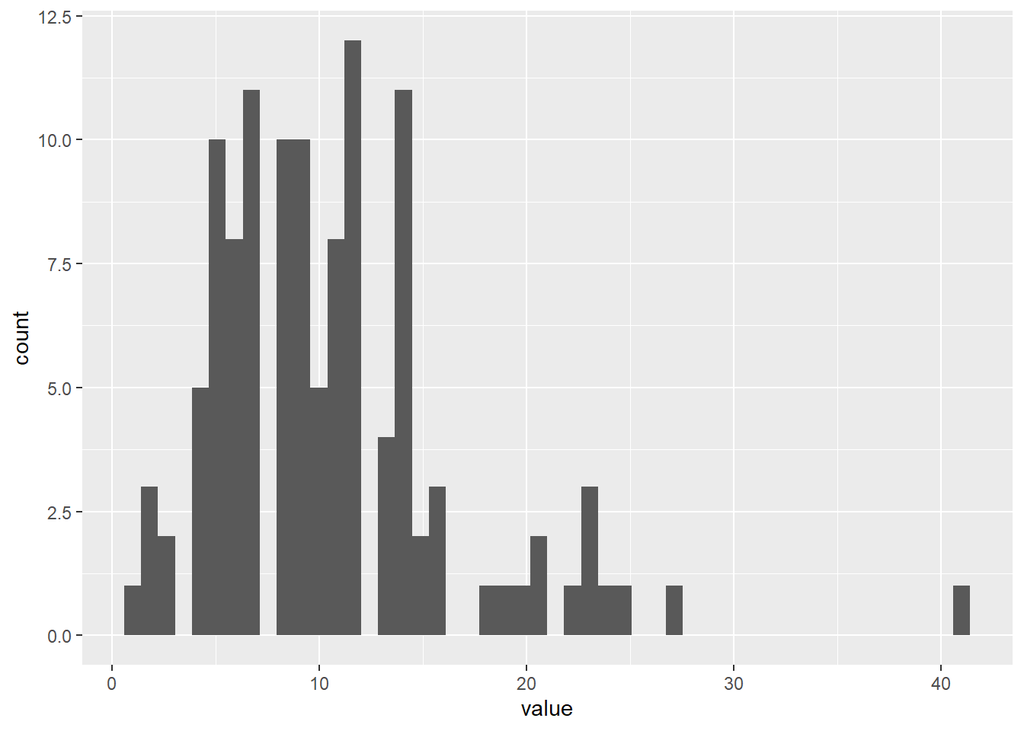

```r
ggplot(laselva, aes(value)) +
  geom_histogram(bins = 50)
```

## Distribution check

- We checked the distribution of the count variable (value) using fitdistrplus::descdist().
- The summary shows:
  - Mean = 10.6
  - Variance (SD²) ≈ 6.04² = 36.48
  - So variance >> mean
- Since the variance was much larger than the mean (variance >> mean), **the data violated the Poisson assumption of mean ≈ variance**. This level of overdispersion is typical of ecological count data, and **therefore a negative binomial** model provides a more appropriate and flexible error structure for the analysis.
- https://cran.r-project.org/web/packages/GlmSimulatoR/vignettes/count_data_and_overdispersion.html
- https://pacificpapermill.com/slideshows/PPM__Poisson_Regression.pdf

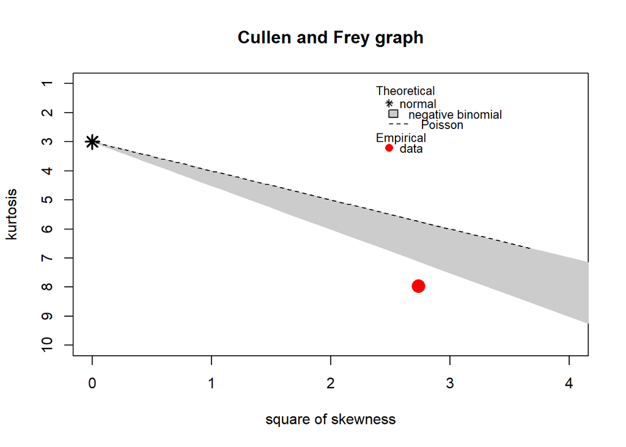

```
## summary statistics
## ------
## min:  1   max:  41
## median:  9
## mean:  10.60169
## estimated sd:  6.041367
## estimated skewness:  1.653916
## estimated kurtosis:  7.959617
```

```r
fitdistrplus::descdist(laselva$value, discrete = TRUE)
```